# Data 607: Assignment 5B

ELO Calculations

Author

Ellie Wilser

## Introduction

For this assignment, I will use the csv file from Project 1 to create an ELO function to calculate different player’s ELO and compare their expected score to their actual score.

I will graph the residuals to better understand how well did the expected score predict how the player would do. This will allow me to see if there are any outlier players in the tournament.

## Approach

I did not choose the provided chess text file to turn into csv for Project 1, so I will be using Gemini to quickly turn the text file into a csv.

After I get the csv file, I will load it into R and store it in this repository.

I will take a functional approach for this assignment. I create an expected score function and compare this to the players actual score. Next, I will create different plots using `ggplot2` to see how well the expected value did at predicting the players score. I will not evaluate the formula, but see if players performed out of the ordinary.

## Code

I tried using Gemini to turn the text file into a csv, but I found using Excel and doing the reformatting much easier.

### Loading Library and Data

```r
library(ggplot2)
library(dplyr)
library(tidyr)
library(gt)
library(tidyverse)
```

```r
url <- "https://raw.githubusercontent.com/EllieWilser/Data_607/refs/heads/main/Assignment_5/Assignment_5B/chess_tournament.csv"

chess_raw <- read.csv(url)

names(chess_raw)
```

```
 [1] "Pair"                 "State"                "Player.Name"
 [4] "USCF.ID"              "Pre.Rating"           "Post.Rating"
 [7] "Total.Pts"            "Norm"                 "Results_Round_1"
[10] "Opponet_Round_1"      "Player_Color_Round_1" "Results_Round_2"
[13] "Opponet_Round_2"      "Player_Color_Round_2" "Results_Round_3"
[16] "Opponet_Round_3"      "Player_Color_Round_3" "Results_Round_4"
[19] "Opponet_Round_4"      "Player_Color_Round_4" "Results_Round_5"
[22] "Opponet_Round_5"      "Player_Color_Round_5" "Results_Round_6"
[25] "Opponet_Round_6"      "Player_Color_Round_6" "Results_Round_7"
[28] "Opponet_Round_7"      "Player_Color_Round_7"
```

### Tidying Data

In order to tidy this data, I need to separate the player information from the different matches, and then pivot match the table to be long format. This was very straight forward with the players summary because it’s just cleaning the rating column and then selecting the needed columns. Pivoting the match was more difficult and required some research.

I looked up a few examples of using pivot longer with multiple columns which helped me figure out how to turn the raw data into a tidy format. I selected columns using the `starts_with()` functions to get the columns that have variables encoded in the name.

I used the `names_to` and `names_pattern` parameters to create the columns “Opponent”, “Player_Color”, “Results” and another column that represents the different round numbers. The pattern uses the naming convention I used when turning the text file into a csv. All text in the untidy columns before “Round” is gets turned into a value column and text after is the different round number. This was great practice for me and helped me better understand how important tidying data is!

```r
players_lookup <- chess_raw %>%
  mutate(
    # Turning rating into numeric and extracting only the leading digits
    pre.rating.clean = as.numeric(str_extract(Pre.Rating, "^\\d+"))
  ) %>%
  select(Pair, Player.Name, pre.rating.clean)

matches_long <- chess_raw %>%
  mutate(pre.rating.clean = as.numeric(str_extract(Pre.Rating, "^\\d+"))) %>%
  pivot_longer(
    cols = c(starts_with("Results_Round_"), starts_with("Opponet_Round_"), starts_with("Player_Color_Round_")),
    names_to = c(".value", "Round_Num"),
    names_pattern = "(.*)_Round_(.*)"
  ) %>%
  rename(
    Match_Result = Results,
    Opponent_Pair = Opponet
  )
```

### Defining Function

I decided to take a functional approach to assignment, and used the elo formula found on [GeeksforGeeks](https://www.geeksforgeeks.org/dsa/elo-rating-algorithm/). I did not update ratings as this has been done already.

```r
calc_elo <- function(rating_a,rating_b) {
  1 / (1 + 10^((rating_b - rating_a) / 400))
}
```

### Implementation and Analysis

For implementing the function, I brought in the opponents data into my match and then calculated the expected ELO score, as well as, added in the actual game score. I had to do some research on what the different letters in the results column meant.

For the player summary, I added together all the actual scores and ELO scores to get the overall scores for the tournament. Then I took the different to get a better understanding of the under and over performers for the tournament.

```r
match_analysis <- matches_long %>%
  left_join(players_lookup, by = c("Opponent_Pair" = "Pair"), suffix = c("", "_Opp")) %>%
  mutate(
    expected_game_score = calc_elo(pre.rating.clean, pre.rating.clean_Opp),
    actual_game_score = case_when(
      Match_Result == "W" ~ 1.0,
      Match_Result %in% c("D","H") ~ 0.5,
      Match_Result %in% c("L","U") ~ 0 )

    )


player_summary <- match_analysis %>%
  group_by(Pair, Player.Name, pre.rating.clean, Total.Pts) %>%
  summarize(
    calculated_actual = sum(actual_game_score, na.rm = TRUE),
    expected_score = sum(expected_game_score, na.rm = TRUE),
    score_diff = calculated_actual - expected_score,
    .groups = "drop"
  )
```

### Graphing

For this graphs, I used a the [r graph gallery](https://r-graph-gallery.com/) as a reference and used gemini lite when I got stuck a few time.

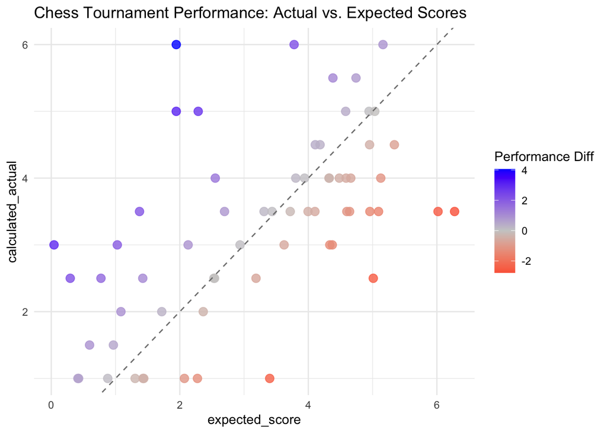

```r
ggplot(player_summary, aes(x = expected_score, y = calculated_actual)) +
  geom_point(aes(color = score_diff), size = 3, alpha = 0.8) +
  # 1:1 Line for Reference
  geom_abline(slope = 1, intercept = 0, linetype = "dashed", color = "gray50") +
  scale_color_gradient2(low = "red", mid = "gray80", high = "blue", midpoint = 0) +
  labs(
    title = "Chess Tournament Performance: Actual vs. Expected Scores",
    color = "Performance Diff"
  ) +
  theme_minimal()
```

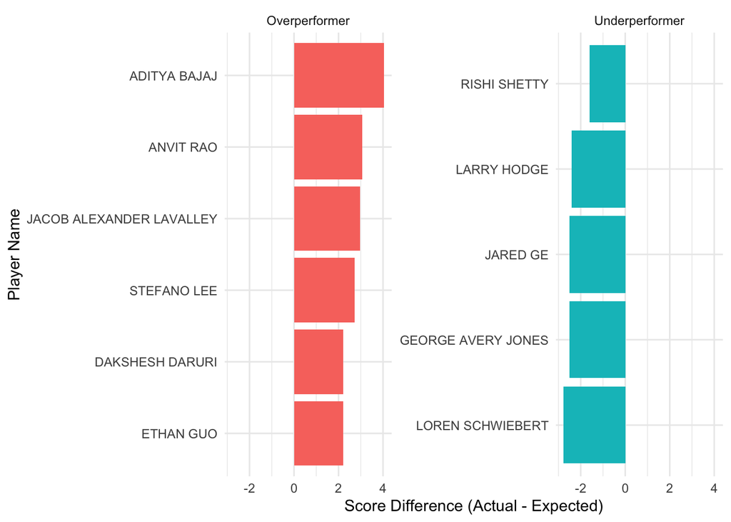

```r
over_under_players <- player_summary %>%
  mutate(rank = rank(score_diff)) %>%
  mutate(category = case_when(
    rank <= 5 ~ "Underperformer",
    rank >= max(rank)-5 ~ "Overperformer"
  )) %>%
  filter(rank <= 5 | rank >= max(rank)-5)

ggplot(over_under_players, aes(x = reorder(Player.Name, score_diff), y = score_diff, fill = category)) +
  geom_col(show.legend = FALSE) +
  coord_flip() +
  facet_wrap(~category, scales = "free_y") +
  labs(
    x = "Player Name",
    y = "Score Difference (Actual - Expected)"
  ) +
  theme_minimal()
```

## Conclusion

In this assignment, I got practice tidying a very messy data file, implementing ELO scoring and creating graphs in ggplot. I enjoyed the practice I got with pivoting a complex data file, as well as creating the different plots. For future investigations, I’d recommend implementing ELO ratings for another competition and predicting the outcomes before games happen.

### AI Usage

For this assignment, I used Gemini lite-fast version to create an initial csv file from txt file, and to create examples of code when I got stuck in the assignment.

### References

Google. (2026). *Gemini* (Large language model) [Computer software]. [https://gemini.google.com](https://gemini.google.com?utm_source=gemini)